# Practical Machine Learning - Project

#### author: Miguel Elduque

#### 29th May 2016

### Project description:

Giving a set of data coming from a different accelerometers on the belt, forearm, arm and dubell of 6 participants we are going to define an algorithm to identify if a give exercise (in our case barbell) is executed correctly.

### Executive Summary:

#### **Load Test and Training Data sets:**

```r
setwd("~/Dropbox/Coursera/Practical Machine Learning"); require(caret) ; require(doMC)

training = read.csv("pml-training.csv", na.strings=c("NA",""), dec = ".")
test = read.csv("pml-testing.csv", dec =".")
```

#### **Data pre-processing:**

There are a lot of columns in the data set and we can see in the summary that there are a large number of NA in them.

I exclude those columns that contain more than 80% of entries = NA (80% of 19622 obs = 15697). We keep 60 variables that will be the entry for our model. I take this approach based on the performance problems that can be derived from large number of predictors and following some advice found in the forum of the course.

```r
cut<-apply(!is.na(training),2,sum)>15697
training_cut<-training[,cut] ;
test_cut<-test[,cut]
```

I exclude as well the 7th first rows as they do not contain data useful for prediction.

In addition, and due to performance problems i am taking only a subset of the overall training data set for the model train. Results of the model should confirm if this approach is valid or should be revisited.

Finally i check there are no variables on the training set which meet the near-zero-variance test.

```r
colnames(training_cut)[1:7]
```

```
## [1] "X"                    "user_name"            "raw_timestamp_part_1"
## [4] "raw_timestamp_part_2" "cvtd_timestamp"       "new_window"
## [7] "num_window"
```

```r
training_cut2<- training_cut[,8:length(colnames(training_cut))]
test_cut2<- test_cut[,8:length(colnames(test_cut))]

set.seed(88888)
train_subset<-createDataPartition(y=training_cut2$classe,p=0.3,list=FALSE)
train_subset_allCols <-createDataPartition(y=training_cut$classe,p=0.3,list=FALSE)

training1<-training_cut2[train_subset,] ; test1<-training_cut2[-train_subset,]
training_allCols<-training_cut[train_subset,] ; test1_allCols<-training_cut[-train_subset,]

nzv <- nearZeroVar(training1)
```

Near Zero Value = 0 so there are **no variables to exclude.**

I have calculated several models to select the best algorithm. The code for all of them can be found in the .rmd file.

Code below is an example of how i have executed the different models:

```r
registerDoMC(cores = 5); start.time <- Sys.time()

model_1<-train(classe~.,data=training1,method="rf",
                trControl=trainControl(method="cv",number=5),
                prox=TRUE,allowParallel=TRUE)

end.time <- Sys.time(); time.taken_model1 <- end.time - start.time

predict_test1_model1 = predict(model_1, test1)
predict_quiz_model1 = predict(model_1, test_cut)

print(confusionMatrix(predict_test1_model1, test1$classe), digits=4)
```

```
## Confusion Matrix and Statistics
##
##           Reference
## Prediction    A    B    C    D    E
##          A 3882   55    0    0    0
##          B   11 2560   46    2    3
##          C    3   34 2326   50    9
##          D   10    6   23 2194   23
##          E    0    2    0    5 2489
##
## Overall Statistics
##
##                Accuracy : 0.9795
##                  95% CI : (0.977, 0.9818)
##     No Information Rate : 0.2844
##     P-Value [Acc > NIR] : < 2.2e-16
##
##                   Kappa : 0.974
##  Mcnemar's Test P-Value : NA
##
## Statistics by Class:
##
##                      Class: A Class: B Class: C Class: D Class: E
## Sensitivity            0.9939   0.9635   0.9712   0.9747   0.9861
## Specificity            0.9944   0.9944   0.9915   0.9946   0.9994
## Pos Pred Value         0.9860   0.9764   0.9604   0.9725   0.9972
## Neg Pred Value         0.9976   0.9913   0.9939   0.9950   0.9969
## Prevalence             0.2844   0.1935   0.1744   0.1639   0.1838
## Detection Rate         0.2827   0.1864   0.1694   0.1598   0.1812
## Detection Prevalence   0.2867   0.1909   0.1764   0.1643   0.1818
## Balanced Accuracy      0.9941   0.9789   0.9814   0.9846   0.9928
```

#### **Summary of models used sorted from higher accuracy to lower:**

**1) Random forest using all the variables**

Accuracy = 0.9997087

Results for the quiz = A, A, A, A, A, A, A, A, A, A, A, A, A, A, A, A, A, A, A, A

Results from the quiz show overfitting. This model is therefore not chosen.

**2) Random forest without Cross-Validation**

Accuracy = 0.9799024

Results for the quiz = B, A, B, A, A, E, D, D, A, A, B, C, B, A, E, E, A, B, B, B

Execution time = 2.2225603

**3) Random forest using 5-fold Cross-Validation:**

Accuracy = 0.9794655

Results for the quiz = B, A, B, A, A, E, D, B, A, A, B, C, B, A, E, E, A, B, B, B

Execution time = 11.2735286

**4) GBM model no Cross-Validation**

Accuracy = 0.9552174

Results for the quiz = B, A, B, A, A, E, D, B, A, A, B, C, B, A, E, E, A, B, B, B

Execution time = 11.1832759

**5) Method NB**

Accuracy = 0.7210369

Results for the quiz = A, A, A, A, A, E, D, E, A, A, A, A, B, A, E, B, A, B, A, B

Execution time = 37.6757922

**6) Neural Networks**

Accuracy = 0.3895726

Results for the quiz = B, B, B, A, B, D, D, E, A, A, A, A, E, A, D, A, A, B, B, B

Execution time = 10.6081549

```r
confusionMatrix(predict_test1_model1 , test1$classe)$overall[1]
time.taken_model1
```

[output not shown]

Finally we can see the most important variables that my selected model considers:

```r
rfVarImp <- varImp(model_1, scale = TRUE)
```

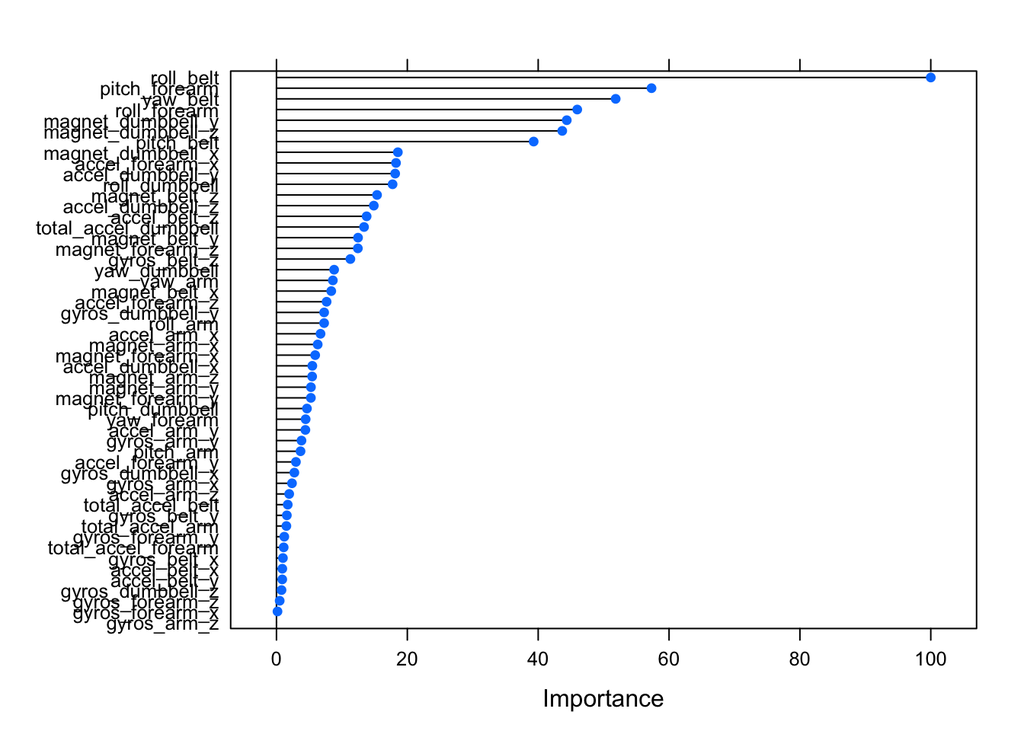

```r
plot(rfVarImp)
```